# Rail Trail t Test

```r
library(mosaic)
library(DT)
library(pander)
library(tidyverse)
library(car)
```

## Question and Hypothesis

My question is whether the average temperature in the spring is greater than the average temperature in the fall. My hypothesis is as follows:

$$H_0: \mu_1 = \mu_2$$
$$H_a: \mu_1 > \mu_2$$

$\mu_1 = Spring\, Average \, Temperature\\$

$\mu_2 = Fall\, Average \, Temperature$

I think that this would be an interesting test since these two seasons are right before and after summer and I usually think of spring being warmer than fall. I will use an independent t-test to test my hypothesis, with a confidence interval of .95.

## Testing for Normal Distribution

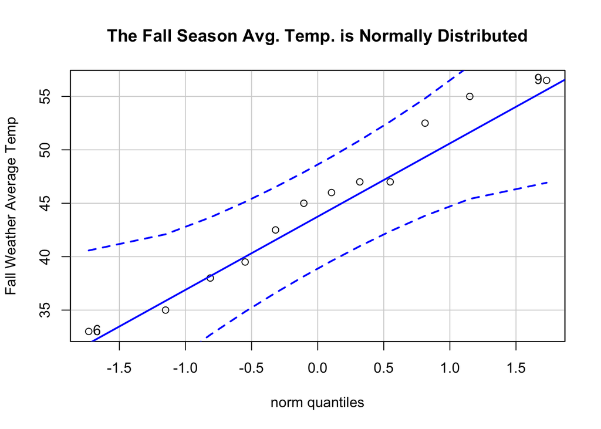

```r
SpringWeather <- subset(RailTrail,RailTrail$spring == 1)
FallWeather <- subset(RailTrail, RailTrail$fall == 1)
# qqplot(SpringWeather$avgtemp,FallWeather$avgtemp, xlab="Spring Weather Avg. Temp", ylab = "Fall Weather Avg. Temp.", main = "The average temp. data provided for fall and spring is normal")

pander(qqPlot(FallWeather$avgtemp, ylab= "Fall Weather Average Temp", main = "The Fall Season Avg. Temp. is Normally Distributed"))
```

*6* and *9*

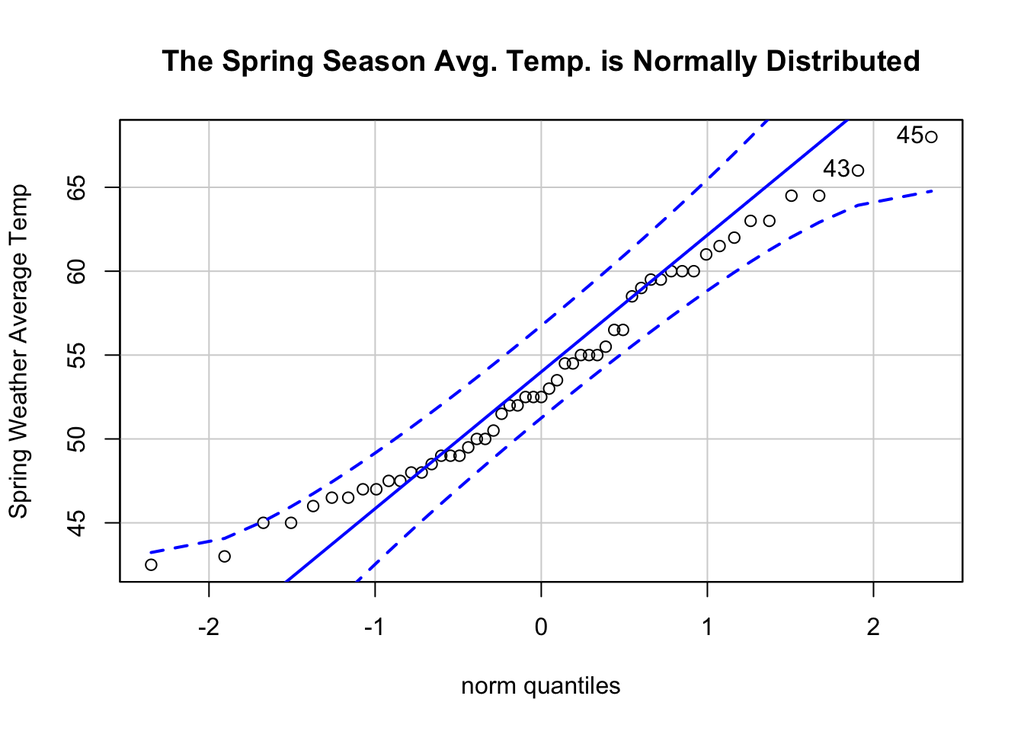

```r
pander(qqPlot(SpringWeather$avgtemp, ylab= "Spring Weather Average Temp", main = "The Spring Season Avg. Temp. is Normally Distributed"))
```

*45* and *43*

#### QQPlot Description

I included the above chart to show that the data is normal and therefore a t-test can be done on the data since there are two requirement for a t-test. One is that the data is representative of the population. The second is that the data is normally distributed. Since the data above follows a straight 45 degree line, the data can be assumed to be normal.

## My Independent Samples T-Test

```r
t.test(SpringWeather$avgtemp, FallWeather$avgtemp, mu = 0, alternative = "greater", conf.level = .95)
```

```
##
##  Welch Two Sample t-test
##
## data:  SpringWeather$avgtemp and FallWeather$avgtemp
## t = 3.8141, df = 14.845, p-value = 0.0008613
## alternative hypothesis: true difference in means is greater than 0
## 95 percent confidence interval:
##  4.842707      Inf
## sample estimates:
## mean of x mean of y
##  53.71698  44.75000
```

#### T-Test Results

The p value is .00086, which is definitely lower than my $\alpha$ of .05, which means that I reject the null hypothesis in favor of the alternative. This shows that the alternative hypothesis that spring average temperatures are greater has some credibility.

## Box plot of fall and spring average temperatures

To further strengthen the alternative hypothesis, I included box plots below.

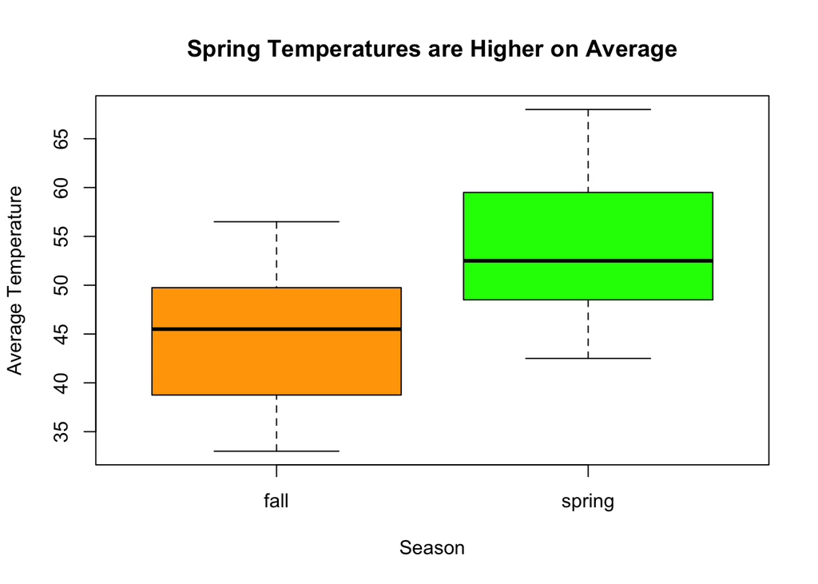

```r
SpringorFall <- subset(RailTrail, fall == 1 | spring == 1 )
SFFiltered <-
  SpringorFall %>%
  gather('spring','fall',key="Season",value = 'SeasonNumber')
SFnew <- subset(SFFiltered, SFFiltered$SeasonNumber != 0)
boxplot(avgtemp ~ Season, data=SFnew, xlab = "Season", ylab = "Average Temperature", main = "Spring Temperatures are Higher on Average", col = c("orange", "green"))
```

```r
FallOnly <- subset(SFnew, SFnew$Season == "Fall")
SpringOnly <- subset(SFnew, SFnew$Season == "Spring")
```

## Spring Average Temperature Summary

```r
pander(favstats(SpringWeather$avgtemp))
```

| min | Q1 | median | Q3 | max | mean | sd | n | missing |
| --- | --- | --- | --- | --- | --- | --- | --- | --- |
| 42.5 | 48.5 | 52.5 | 59.5 | 68 | 53.72 | 6.442 | 53 | 0 |

## Fall Average Temperature Summary

```r
pander(favstats(FallWeather$avgtemp))
```

| min | Q1 | median | Q3 | max | mean | sd | n | missing |
| --- | --- | --- | --- | --- | --- | --- | --- | --- |
| 33 | 39.12 | 45.5 | 48.38 | 56.5 | 44.75 | 7.545 | 12 | 0 |

#### Average Temperature Summary Explanation

I included a summary of the average temperature data so that the data represented in the box plots is easier to see.

## Interpretation

Spring did turn out to be a hotter season than fall. It was surprising to see that they were relatively close in temperature though. One interesting thing that I saw was that the fall median temperature was closer to the 75th percentile and the spring median temperature was closer to the 25th percentile. This tells me that there was greater variation in temperatures for fall in the 25-50th percentiles and for spring in the 50th to 75th percentiles. This would make sense because the temperatures in fall would be cooling down and spring would be warming up. Overall, the alternative hypothesis was found to be more correct based on the information given.